# Risk Factor Analysis

## Outcome Variable

**Outcome Variable:** wast_rec90d

## Predictor Variables

**Intervention Variable:** birthlen

**Adjustment Set:**

- arm
- sex
- W_mage
- meducyrs
- feducyrs
- vagbrth
- brthmon
- W_parity
- impsan
- delta_W_mage
- delta_meducyrs
- delta_feducyrs
- delta_vagbrth
- delta_brthmon
- delta_W_parity
- delta_impsan

## Stratifying Variables

The analysis was stratified on these variable(s):

- agecat
- studyid
- country

## Data Summary

| agecat | studyid | country | birthlen | wast_rec90d | n_cell | n |
| --- | --- | --- | --- | --- | --- | --- |
| 0-24 months | ki0047075b-MAL-ED | BANGLADESH | >=50 cm | 0 | 4 | 119 |
| 0-24 months | ki0047075b-MAL-ED | BANGLADESH | >=50 cm | 1 | 12 | 119 |
| 0-24 months | ki0047075b-MAL-ED | BANGLADESH | <48 cm | 0 | 25 | 119 |
| 0-24 months | ki0047075b-MAL-ED | BANGLADESH | <48 cm | 1 | 43 | 119 |
| 0-24 months | ki0047075b-MAL-ED | BANGLADESH | [48-50) cm | 0 | 15 | 119 |
| 0-24 months | ki0047075b-MAL-ED | BANGLADESH | [48-50) cm | 1 | 20 | 119 |
| 0-24 months | ki0047075b-MAL-ED | BRAZIL | >=50 cm | 0 | 0 | 22 |
| 0-24 months | ki0047075b-MAL-ED | BRAZIL | >=50 cm | 1 | 6 | 22 |
| 0-24 months | ki0047075b-MAL-ED | BRAZIL | <48 cm | 0 | 3 | 22 |
| 0-24 months | ki0047075b-MAL-ED | BRAZIL | <48 cm | 1 | 6 | 22 |
| 0-24 months | ki0047075b-MAL-ED | BRAZIL | [48-50) cm | 0 | 2 | 22 |
| 0-24 months | ki0047075b-MAL-ED | BRAZIL | [48-50) cm | 1 | 5 | 22 |
| 0-24 months | ki0047075b-MAL-ED | INDIA | >=50 cm | 0 | 3 | 144 |
| 0-24 months | ki0047075b-MAL-ED | INDIA | >=50 cm | 1 | 9 | 144 |
| 0-24 months | ki0047075b-MAL-ED | INDIA | <48 cm | 0 | 35 | 144 |
| 0-24 months | ki0047075b-MAL-ED | INDIA | <48 cm | 1 | 45 | 144 |
| 0-24 months | ki0047075b-MAL-ED | INDIA | [48-50) cm | 0 | 19 | 144 |
| 0-24 months | ki0047075b-MAL-ED | INDIA | [48-50) cm | 1 | 33 | 144 |
| 0-24 months | ki0047075b-MAL-ED | NEPAL | >=50 cm | 0 | 4 | 72 |
| 0-24 months | ki0047075b-MAL-ED | NEPAL | >=50 cm | 1 | 8 | 72 |
| 0-24 months | ki0047075b-MAL-ED | NEPAL | <48 cm | 0 | 8 | 72 |
| 0-24 months | ki0047075b-MAL-ED | NEPAL | <48 cm | 1 | 38 | 72 |
| 0-24 months | ki0047075b-MAL-ED | NEPAL | [48-50) cm | 0 | 1 | 72 |
| 0-24 months | ki0047075b-MAL-ED | NEPAL | [48-50) cm | 1 | 13 | 72 |
| 0-24 months | ki0047075b-MAL-ED | PERU | >=50 cm | 0 | 0 | 34 |
| 0-24 months | ki0047075b-MAL-ED | PERU | >=50 cm | 1 | 4 | 34 |
| 0-24 months | ki0047075b-MAL-ED | PERU | <48 cm | 0 | 5 | 34 |
| 0-24 months | ki0047075b-MAL-ED | PERU | <48 cm | 1 | 17 | 34 |
| 0-24 months | ki0047075b-MAL-ED | PERU | [48-50) cm | 0 | 1 | 34 |
| 0-24 months | ki0047075b-MAL-ED | PERU | [48-50) cm | 1 | 7 | 34 |

[output cut: 444 more lines]

The following strata were considered:

- agecat: 0-24 months, studyid: ki0047075b-MAL-ED, country: BANGLADESH
- agecat: 0-24 months, studyid: ki0047075b-MAL-ED, country: BRAZIL
- agecat: 0-24 months, studyid: ki0047075b-MAL-ED, country: INDIA
- agecat: 0-24 months, studyid: ki0047075b-MAL-ED, country: NEPAL
- agecat: 0-24 months, studyid: ki0047075b-MAL-ED, country: PERU
- agecat: 0-24 months, studyid: ki0047075b-MAL-ED, country: SOUTH AFRICA
- agecat: 0-24 months, studyid: ki0047075b-MAL-ED, country: TANZANIA, UNITED REPUBLIC OF
- agecat: 0-24 months, studyid: ki1000108-CMC-V-BCS-2002, country: INDIA
- agecat: 0-24 months, studyid: ki1000108-IRC, country: INDIA
- agecat: 0-24 months, studyid: ki1000109-EE, country: PAKISTAN
- agecat: 0-24 months, studyid: ki1000109-ResPak, country: PAKISTAN
- agecat: 0-24 months, studyid: ki1000304b-SAS-CompFeed, country: INDIA
- agecat: 0-24 months, studyid: ki1017093-NIH-Birth, country: BANGLADESH
- agecat: 0-24 months, studyid: ki1017093b-PROVIDE, country: BANGLADESH
- agecat: 0-24 months, studyid: ki1017093c-NIH-Crypto, country: BANGLADESH
- agecat: 0-24 months, studyid: ki1101329-Keneba, country: GAMBIA
- agecat: 0-24 months, studyid: ki1114097-CMIN, country: BANGLADESH
- agecat: 0-24 months, studyid: ki1114097-CMIN, country: BRAZIL
- agecat: 0-24 months, studyid: ki1114097-CMIN, country: GUINEA-BISSAU
- agecat: 0-24 months, studyid: ki1114097-CMIN, country: PERU
- agecat: 0-24 months, studyid: ki1119695-PROBIT, country: BELARUS
- agecat: 0-24 months, studyid: ki1126311-ZVITAMBO, country: ZIMBABWE
- agecat: 0-24 months, studyid: ki1135781-COHORTS, country: GUATEMALA
- agecat: 0-24 months, studyid: ki1135781-COHORTS, country: INDIA
- agecat: 0-24 months, studyid: ki1135781-COHORTS, country: PHILIPPINES
- agecat: 0-24 months, studyid: kiGH5241-JiVitA-3, country: BANGLADESH
- agecat: 0-24 months, studyid: kiGH5241-JiVitA-4, country: BANGLADESH
- agecat: 0-6 months, studyid: ki0047075b-MAL-ED, country: BANGLADESH
- agecat: 0-6 months, studyid: ki0047075b-MAL-ED, country: BRAZIL
- agecat: 0-6 months, studyid: ki0047075b-MAL-ED, country: INDIA
- agecat: 0-6 months, studyid: ki0047075b-MAL-ED, country: NEPAL
- agecat: 0-6 months, studyid: ki0047075b-MAL-ED, country: PERU
- agecat: 0-6 months, studyid: ki0047075b-MAL-ED, country: SOUTH AFRICA
- agecat: 0-6 months, studyid: ki0047075b-MAL-ED, country: TANZANIA, UNITED REPUBLIC OF
- agecat: 0-6 months, studyid: ki1000108-CMC-V-BCS-2002, country: INDIA
- agecat: 0-6 months, studyid: ki1000108-IRC, country: INDIA
- agecat: 0-6 months, studyid: ki1000109-EE, country: PAKISTAN
- agecat: 0-6 months, studyid: ki1000109-ResPak, country: PAKISTAN
- agecat: 0-6 months, studyid: ki1000304b-SAS-CompFeed, country: INDIA
- agecat: 0-6 months, studyid: ki1017093-NIH-Birth, country: BANGLADESH
- agecat: 0-6 months, studyid: ki1017093b-PROVIDE, country: BANGLADESH
- agecat: 0-6 months, studyid: ki1017093c-NIH-Crypto, country: BANGLADESH
- agecat: 0-6 months, studyid: ki1101329-Keneba, country: GAMBIA
- agecat: 0-6 months, studyid: ki1114097-CMIN, country: BANGLADESH
- agecat: 0-6 months, studyid: ki1114097-CMIN, country: BRAZIL
- agecat: 0-6 months, studyid: ki1114097-CMIN, country: GUINEA-BISSAU
- agecat: 0-6 months, studyid: ki1114097-CMIN, country: PERU
- agecat: 0-6 months, studyid: ki1119695-PROBIT, country: BELARUS
- agecat: 0-6 months, studyid: ki1126311-ZVITAMBO, country: ZIMBABWE
- agecat: 0-6 months, studyid: ki1135781-COHORTS, country: GUATEMALA
- agecat: 0-6 months, studyid: ki1135781-COHORTS, country: INDIA
- agecat: 0-6 months, studyid: ki1135781-COHORTS, country: PHILIPPINES
- agecat: 0-6 months, studyid: kiGH5241-JiVitA-3, country: BANGLADESH
- agecat: 0-6 months, studyid: kiGH5241-JiVitA-4, country: BANGLADESH
- agecat: 6-24 months, studyid: ki0047075b-MAL-ED, country: BANGLADESH
- agecat: 6-24 months, studyid: ki0047075b-MAL-ED, country: BRAZIL
- agecat: 6-24 months, studyid: ki0047075b-MAL-ED, country: INDIA
- agecat: 6-24 months, studyid: ki0047075b-MAL-ED, country: NEPAL
- agecat: 6-24 months, studyid: ki0047075b-MAL-ED, country: PERU
- agecat: 6-24 months, studyid: ki0047075b-MAL-ED, country: SOUTH AFRICA
- agecat: 6-24 months, studyid: ki0047075b-MAL-ED, country: TANZANIA, UNITED REPUBLIC OF
- agecat: 6-24 months, studyid: ki1000108-CMC-V-BCS-2002, country: INDIA
- agecat: 6-24 months, studyid: ki1000108-IRC, country: INDIA
- agecat: 6-24 months, studyid: ki1000109-EE, country: PAKISTAN
- agecat: 6-24 months, studyid: ki1000109-ResPak, country: PAKISTAN
- agecat: 6-24 months, studyid: ki1000304b-SAS-CompFeed, country: INDIA
- agecat: 6-24 months, studyid: ki1017093-NIH-Birth, country: BANGLADESH
- agecat: 6-24 months, studyid: ki1017093b-PROVIDE, country: BANGLADESH
- agecat: 6-24 months, studyid: ki1017093c-NIH-Crypto, country: BANGLADESH
- agecat: 6-24 months, studyid: ki1101329-Keneba, country: GAMBIA
- agecat: 6-24 months, studyid: ki1114097-CMIN, country: BRAZIL
- agecat: 6-24 months, studyid: ki1114097-CMIN, country: PERU
- agecat: 6-24 months, studyid: ki1119695-PROBIT, country: BELARUS
- agecat: 6-24 months, studyid: ki1126311-ZVITAMBO, country: ZIMBABWE
- agecat: 6-24 months, studyid: ki1135781-COHORTS, country: GUATEMALA
- agecat: 6-24 months, studyid: ki1135781-COHORTS, country: INDIA
- agecat: 6-24 months, studyid: ki1135781-COHORTS, country: PHILIPPINES
- agecat: 6-24 months, studyid: kiGH5241-JiVitA-3, country: BANGLADESH
- agecat: 6-24 months, studyid: kiGH5241-JiVitA-4, country: BANGLADESH

### Dropped Strata

Some strata were dropped due to rare outcomes:

- agecat: 0-24 months, studyid: ki0047075b-MAL-ED, country: BANGLADESH
- agecat: 0-24 months, studyid: ki0047075b-MAL-ED, country: BRAZIL
- agecat: 0-24 months, studyid: ki0047075b-MAL-ED, country: INDIA
- agecat: 0-24 months, studyid: ki0047075b-MAL-ED, country: NEPAL
- agecat: 0-24 months, studyid: ki0047075b-MAL-ED, country: PERU
- agecat: 0-24 months, studyid: ki0047075b-MAL-ED, country: SOUTH AFRICA
- agecat: 0-24 months, studyid: ki0047075b-MAL-ED, country: TANZANIA, UNITED REPUBLIC OF
- agecat: 0-24 months, studyid: ki1000108-CMC-V-BCS-2002, country: INDIA
- agecat: 0-24 months, studyid: ki1000109-ResPak, country: PAKISTAN
- agecat: 0-24 months, studyid: ki1114097-CMIN, country: BANGLADESH
- agecat: 0-24 months, studyid: ki1114097-CMIN, country: BRAZIL
- agecat: 0-24 months, studyid: ki1114097-CMIN, country: GUINEA-BISSAU
- agecat: 0-24 months, studyid: ki1114097-CMIN, country: PERU
- agecat: 0-6 months, studyid: ki0047075b-MAL-ED, country: BANGLADESH
- agecat: 0-6 months, studyid: ki0047075b-MAL-ED, country: BRAZIL
- agecat: 0-6 months, studyid: ki0047075b-MAL-ED, country: INDIA
- agecat: 0-6 months, studyid: ki0047075b-MAL-ED, country: NEPAL
- agecat: 0-6 months, studyid: ki0047075b-MAL-ED, country: PERU
- agecat: 0-6 months, studyid: ki0047075b-MAL-ED, country: SOUTH AFRICA
- agecat: 0-6 months, studyid: ki0047075b-MAL-ED, country: TANZANIA, UNITED REPUBLIC OF
- agecat: 0-6 months, studyid: ki1000108-CMC-V-BCS-2002, country: INDIA
- agecat: 0-6 months, studyid: ki1000109-EE, country: PAKISTAN
- agecat: 0-6 months, studyid: ki1000109-ResPak, country: PAKISTAN
- agecat: 0-6 months, studyid: ki1017093-NIH-Birth, country: BANGLADESH
- agecat: 0-6 months, studyid: ki1017093c-NIH-Crypto, country: BANGLADESH
- agecat: 0-6 months, studyid: ki1114097-CMIN, country: BANGLADESH
- agecat: 0-6 months, studyid: ki1114097-CMIN, country: BRAZIL
- agecat: 0-6 months, studyid: ki1114097-CMIN, country: GUINEA-BISSAU
- agecat: 0-6 months, studyid: ki1114097-CMIN, country: PERU
- agecat: 6-24 months, studyid: ki0047075b-MAL-ED, country: BANGLADESH
- agecat: 6-24 months, studyid: ki0047075b-MAL-ED, country: BRAZIL
- agecat: 6-24 months, studyid: ki0047075b-MAL-ED, country: INDIA
- agecat: 6-24 months, studyid: ki0047075b-MAL-ED, country: NEPAL
- agecat: 6-24 months, studyid: ki0047075b-MAL-ED, country: PERU
- agecat: 6-24 months, studyid: ki0047075b-MAL-ED, country: SOUTH AFRICA
- agecat: 6-24 months, studyid: ki0047075b-MAL-ED, country: TANZANIA, UNITED REPUBLIC OF
- agecat: 6-24 months, studyid: ki1000108-CMC-V-BCS-2002, country: INDIA
- agecat: 6-24 months, studyid: ki1000109-EE, country: PAKISTAN
- agecat: 6-24 months, studyid: ki1000109-ResPak, country: PAKISTAN
- agecat: 6-24 months, studyid: ki1017093-NIH-Birth, country: BANGLADESH
- agecat: 6-24 months, studyid: ki1017093b-PROVIDE, country: BANGLADESH
- agecat: 6-24 months, studyid: ki1017093c-NIH-Crypto, country: BANGLADESH
- agecat: 6-24 months, studyid: ki1114097-CMIN, country: BRAZIL
- agecat: 6-24 months, studyid: ki1114097-CMIN, country: PERU
- agecat: 6-24 months, studyid: ki1119695-PROBIT, country: BELARUS
- agecat: 6-24 months, studyid: ki1135781-COHORTS, country: GUATEMALA
- agecat: 6-24 months, studyid: ki1135781-COHORTS, country: INDIA
- agecat: 6-24 months, studyid: kiGH5241-JiVitA-3, country: BANGLADESH

## Methods Detail

We’re interested in the causal parameters $E[Y_a]$ for all values of $a \in \mathcal{A}$. These parameters represent the mean outcome if, possibly contrary to fact, we intervened to set all units to have $A=a$. Under the randomization and positivity assumptions, these are identified by the statistical parameters $\psi_a=E_W[E_{Y|A,W}(Y|A=a,W)]$. In addition, we’re interested in the mean of $Y$, $E[Y]$ under no intervention (the observed mean). We will estimate these parameters by using SuperLearner to fit the relevant likelihood factors – $E_{Y|A,W}(Y|A=a,W)$ and $p(A=a|W)$, and then updating our likelihood fit using a joint TMLE.

For unadjusted analyses ($W=\{\}$), initial likelihoods were estimated using Lrnr_glm to estimate the simple $E(Y|A)$ and Lrnr_mean to estimate $p(A)$. For adjusted analyses, a small library containing Lrnr_glmnet, Lrnr_xgboost, and Lrnr_mean was used.

Having estimated these parameters, we will then use the delta method to estimate relative risks and attributable risks relative to a prespecified baseline level of $A$.

# Results Detail

## Results Plots

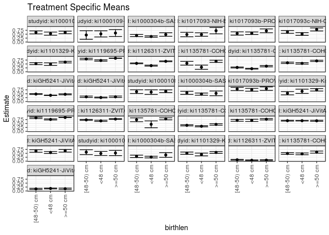

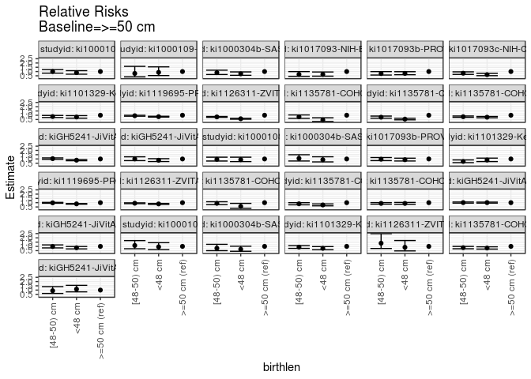

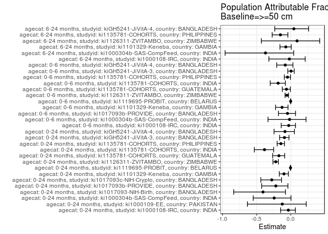

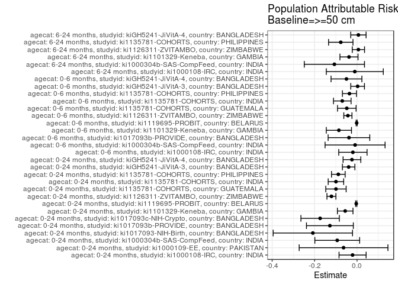

## Results Table

### Parameter: TSM

| agecat | studyid | country | intervention_level | baseline_level | estimate | ci_lower | ci_upper |
| --- | --- | --- | --- | --- | --- | --- | --- |
| 0-24 months | ki1000108-IRC | INDIA | >=50 cm | NA | 0.6101485 | 0.5279569 | 0.6923401 |
| 0-24 months | ki1000108-IRC | INDIA | <48 cm | NA | 0.5317489 | 0.4301358 | 0.6333621 |
| 0-24 months | ki1000108-IRC | INDIA | [48-50) cm | NA | 0.6096822 | 0.5140492 | 0.7053153 |
| 0-24 months | ki1000109-EE | PAKISTAN | >=50 cm | NA | 0.5714286 | 0.3517642 | 0.7910929 |
| 0-24 months | ki1000109-EE | PAKISTAN | <48 cm | NA | 0.5161290 | 0.3192140 | 0.7130441 |
| 0-24 months | ki1000109-EE | PAKISTAN | [48-50) cm | NA | 0.4444444 | 0.1710271 | 0.7178618 |
| 0-24 months | ki1000304b-SAS-CompFeed | INDIA | >=50 cm | NA | 0.4764310 | 0.3631015 | 0.5897605 |
| 0-24 months | ki1000304b-SAS-CompFeed | INDIA | <48 cm | NA | 0.3481832 | 0.3042559 | 0.3921105 |
| 0-24 months | ki1000304b-SAS-CompFeed | INDIA | [48-50) cm | NA | 0.4133144 | 0.3458188 | 0.4808100 |
| 0-24 months | ki1017093-NIH-Birth | BANGLADESH | >=50 cm | NA | 0.7200000 | 0.5200875 | 0.9199125 |
| 0-24 months | ki1017093-NIH-Birth | BANGLADESH | <48 cm | NA | 0.4756098 | 0.3649515 | 0.5862680 |
| 0-24 months | ki1017093-NIH-Birth | BANGLADESH | [48-50) cm | NA | 0.4761905 | 0.3342656 | 0.6181153 |
| 0-24 months | ki1017093b-PROVIDE | BANGLADESH | >=50 cm | NA | 0.7109492 | 0.5887384 | 0.8331600 |
| 0-24 months | ki1017093b-PROVIDE | BANGLADESH | <48 cm | NA | 0.5578802 | 0.4775605 | 0.6381999 |
| 0-24 months | ki1017093b-PROVIDE | BANGLADESH | [48-50) cm | NA | 0.5436967 | 0.4397499 | 0.6476434 |
| 0-24 months | ki1017093c-NIH-Crypto | BANGLADESH | >=50 cm | NA | 0.7977411 | 0.7003503 | 0.8951318 |
| 0-24 months | ki1017093c-NIH-Crypto | BANGLADESH | <48 cm | NA | 0.5097091 | 0.4208017 | 0.5986165 |
| 0-24 months | ki1017093c-NIH-Crypto | BANGLADESH | [48-50) cm | NA | 0.6389934 | 0.5507495 | 0.7272374 |
| 0-24 months | ki1101329-Keneba | GAMBIA | >=50 cm | NA | 0.6150795 | 0.5658461 | 0.6643129 |
| 0-24 months | ki1101329-Keneba | GAMBIA | <48 cm | NA | 0.4876996 | 0.4050759 | 0.5703233 |
| 0-24 months | ki1101329-Keneba | GAMBIA | [48-50) cm | NA | 0.5202740 | 0.4574374 | 0.5831105 |
| 0-24 months | ki1119695-PROBIT | BELARUS | >=50 cm | NA | 0.8648064 | 0.8544839 | 0.8751288 |
| 0-24 months | ki1119695-PROBIT | BELARUS | <48 cm | NA | 0.7200000 | 0.6794039 | 0.7605961 |
| 0-24 months | ki1119695-PROBIT | BELARUS | [48-50) cm | NA | 0.8152610 | 0.7681659 | 0.8623562 |
| 0-24 months | ki1126311-ZVITAMBO | ZIMBABWE | >=50 cm | NA | 0.6666500 | 0.6406366 | 0.6926633 |
| 0-24 months | ki1126311-ZVITAMBO | ZIMBABWE | <48 cm | NA | 0.3919619 | 0.3604848 | 0.4234390 |
| 0-24 months | ki1126311-ZVITAMBO | ZIMBABWE | [48-50) cm | NA | 0.5358114 | 0.5089842 | 0.5626386 |
| 0-24 months | ki1135781-COHORTS | GUATEMALA | >=50 cm | NA | 0.6687437 | 0.5988502 | 0.7386372 |
| 0-24 months | ki1135781-COHORTS | GUATEMALA | <48 cm | NA | 0.2912296 | 0.1566983 | 0.4257609 |
| 0-24 months | ki1135781-COHORTS | GUATEMALA | [48-50) cm | NA | 0.5435415 | 0.4237812 | 0.6633018 |

[output cut: 63 more lines]

### Parameter: E(Y)

| agecat | studyid | country | intervention_level | baseline_level | estimate | ci_lower | ci_upper |
| --- | --- | --- | --- | --- | --- | --- | --- |
| 0-24 months | ki1000108-IRC | INDIA | NA | NA | 0.5891473 | 0.5364145 | 0.6418800 |
| 0-24 months | ki1000109-EE | PAKISTAN | NA | NA | 0.5079365 | 0.3724516 | 0.6434214 |
| 0-24 months | ki1000304b-SAS-CompFeed | INDIA | NA | NA | 0.3831891 | 0.3479331 | 0.4184451 |
| 0-24 months | ki1017093-NIH-Birth | BANGLADESH | NA | NA | 0.5117647 | 0.4302715 | 0.5932579 |
| 0-24 months | ki1017093b-PROVIDE | BANGLADESH | NA | NA | 0.5830619 | 0.5262762 | 0.6398476 |
| 0-24 months | ki1017093c-NIH-Crypto | BANGLADESH | NA | NA | 0.6237942 | 0.5698223 | 0.6777662 |
| 0-24 months | ki1101329-Keneba | GAMBIA | NA | NA | 0.5593036 | 0.5241177 | 0.5944895 |
| 0-24 months | ki1119695-PROBIT | BELARUS | NA | NA | 0.8612051 | 0.8511051 | 0.8713052 |
| 0-24 months | ki1126311-ZVITAMBO | ZIMBABWE | NA | NA | 0.5459916 | 0.5294878 | 0.5624953 |
| 0-24 months | ki1135781-COHORTS | GUATEMALA | NA | NA | 0.5694915 | 0.5120418 | 0.6269413 |
| 0-24 months | ki1135781-COHORTS | INDIA | NA | NA | 0.2579095 | 0.2406335 | 0.2751855 |
| 0-24 months | ki1135781-COHORTS | PHILIPPINES | NA | NA | 0.6067616 | 0.5822457 | 0.6312775 |
| 0-24 months | kiGH5241-JiVitA-3 | BANGLADESH | NA | NA | 0.4249094 | 0.4136873 | 0.4361315 |
| 0-24 months | kiGH5241-JiVitA-4 | BANGLADESH | NA | NA | 0.2796610 | 0.2580570 | 0.3012650 |
| 0-6 months | ki1000108-IRC | INDIA | NA | NA | 0.6398305 | 0.5770134 | 0.7026476 |
| 0-6 months | ki1000304b-SAS-CompFeed | INDIA | NA | NA | 0.5147059 | 0.4610948 | 0.5683169 |
| 0-6 months | ki1017093b-PROVIDE | BANGLADESH | NA | NA | 0.7880435 | 0.7295878 | 0.8464992 |
| 0-6 months | ki1101329-Keneba | GAMBIA | NA | NA | 0.6666667 | 0.6089363 | 0.7243970 |
| 0-6 months | ki1119695-PROBIT | BELARUS | NA | NA | 0.8855266 | 0.8758983 | 0.8951550 |
| 0-6 months | ki1126311-ZVITAMBO | ZIMBABWE | NA | NA | 0.7430390 | 0.7259692 | 0.7601088 |
| 0-6 months | ki1135781-COHORTS | GUATEMALA | NA | NA | 0.7547170 | 0.6968087 | 0.8126253 |
| 0-6 months | ki1135781-COHORTS | INDIA | NA | NA | 0.3750728 | 0.3521661 | 0.3979795 |
| 0-6 months | ki1135781-COHORTS | PHILIPPINES | NA | NA | 0.7363515 | 0.7047428 | 0.7679603 |
| 0-6 months | kiGH5241-JiVitA-3 | BANGLADESH | NA | NA | 0.6779443 | 0.6645427 | 0.6913460 |
| 0-6 months | kiGH5241-JiVitA-4 | BANGLADESH | NA | NA | 0.6130952 | 0.5705324 | 0.6556580 |
| 6-24 months | ki1000108-IRC | INDIA | NA | NA | 0.5099338 | 0.4248374 | 0.5950302 |
| 6-24 months | ki1000304b-SAS-CompFeed | INDIA | NA | NA | 0.2878465 | 0.2457514 | 0.3299415 |
| 6-24 months | ki1101329-Keneba | GAMBIA | NA | NA | 0.5180723 | 0.4773341 | 0.5588105 |
| 6-24 months | ki1126311-ZVITAMBO | ZIMBABWE | NA | NA | 0.0701249 | 0.0547060 | 0.0855437 |
| 6-24 months | ki1135781-COHORTS | PHILIPPINES | NA | NA | 0.5026738 | 0.4688037 | 0.5365439 |
| 6-24 months | kiGH5241-JiVitA-4 | BANGLADESH | NA | NA | 0.1469194 | 0.1276367 | 0.1662021 |

### Parameter: RR

| agecat | studyid | country | intervention_level | baseline_level | estimate | ci_lower | ci_upper |
| --- | --- | --- | --- | --- | --- | --- | --- |
| 0-24 months | ki1000108-IRC | INDIA | >=50 cm | >=50 cm | 1.0000000 | 1.0000000 | 1.0000000 |
| 0-24 months | ki1000108-IRC | INDIA | <48 cm | >=50 cm | 0.8715074 | 0.6894003 | 1.1017185 |
| 0-24 months | ki1000108-IRC | INDIA | [48-50) cm | >=50 cm | 0.9992358 | 0.8121630 | 1.2293987 |
| 0-24 months | ki1000109-EE | PAKISTAN | >=50 cm | >=50 cm | 1.0000000 | 1.0000000 | 1.0000000 |
| 0-24 months | ki1000109-EE | PAKISTAN | <48 cm | >=50 cm | 0.9032258 | 0.5263327 | 1.5500023 |
| 0-24 months | ki1000109-EE | PAKISTAN | [48-50) cm | >=50 cm | 0.7777778 | 0.3767474 | 1.6056865 |
| 0-24 months | ki1000304b-SAS-CompFeed | INDIA | >=50 cm | >=50 cm | 1.0000000 | 1.0000000 | 1.0000000 |
| 0-24 months | ki1000304b-SAS-CompFeed | INDIA | <48 cm | >=50 cm | 0.7308155 | 0.5585496 | 0.9562111 |
| 0-24 months | ki1000304b-SAS-CompFeed | INDIA | [48-50) cm | >=50 cm | 0.8675220 | 0.6502903 | 1.1573207 |
| 0-24 months | ki1017093-NIH-Birth | BANGLADESH | >=50 cm | >=50 cm | 1.0000000 | 1.0000000 | 1.0000000 |
| 0-24 months | ki1017093-NIH-Birth | BANGLADESH | <48 cm | >=50 cm | 0.6605691 | 0.4598630 | 0.9488729 |
| 0-24 months | ki1017093-NIH-Birth | BANGLADESH | [48-50) cm | >=50 cm | 0.6613757 | 0.4401309 | 0.9938357 |
| 0-24 months | ki1017093b-PROVIDE | BANGLADESH | >=50 cm | >=50 cm | 1.0000000 | 1.0000000 | 1.0000000 |
| 0-24 months | ki1017093b-PROVIDE | BANGLADESH | <48 cm | >=50 cm | 0.7846977 | 0.6269543 | 0.9821297 |
| 0-24 months | ki1017093b-PROVIDE | BANGLADESH | [48-50) cm | >=50 cm | 0.7647476 | 0.5911071 | 0.9893957 |
| 0-24 months | ki1017093c-NIH-Crypto | BANGLADESH | >=50 cm | >=50 cm | 1.0000000 | 1.0000000 | 1.0000000 |
| 0-24 months | ki1017093c-NIH-Crypto | BANGLADESH | <48 cm | >=50 cm | 0.6389406 | 0.5161445 | 0.7909511 |
| 0-24 months | ki1017093c-NIH-Crypto | BANGLADESH | [48-50) cm | >=50 cm | 0.8010036 | 0.6661527 | 0.9631527 |
| 0-24 months | ki1101329-Keneba | GAMBIA | >=50 cm | >=50 cm | 1.0000000 | 1.0000000 | 1.0000000 |
| 0-24 months | ki1101329-Keneba | GAMBIA | <48 cm | >=50 cm | 0.7929050 | 0.6574840 | 0.9562184 |
| 0-24 months | ki1101329-Keneba | GAMBIA | [48-50) cm | >=50 cm | 0.8458646 | 0.7318051 | 0.9777014 |
| 0-24 months | ki1119695-PROBIT | BELARUS | >=50 cm | >=50 cm | 1.0000000 | 1.0000000 | 1.0000000 |
| 0-24 months | ki1119695-PROBIT | BELARUS | <48 cm | >=50 cm | 0.8325563 | 0.7859301 | 0.8819487 |
| 0-24 months | ki1119695-PROBIT | BELARUS | [48-50) cm | >=50 cm | 0.9427094 | 0.8887094 | 0.9999905 |
| 0-24 months | ki1126311-ZVITAMBO | ZIMBABWE | >=50 cm | >=50 cm | 1.0000000 | 1.0000000 | 1.0000000 |
| 0-24 months | ki1126311-ZVITAMBO | ZIMBABWE | <48 cm | >=50 cm | 0.5879576 | 0.5377364 | 0.6428692 |
| 0-24 months | ki1126311-ZVITAMBO | ZIMBABWE | [48-50) cm | >=50 cm | 0.8037372 | 0.7543189 | 0.8563932 |
| 0-24 months | ki1135781-COHORTS | GUATEMALA | >=50 cm | >=50 cm | 1.0000000 | 1.0000000 | 1.0000000 |
| 0-24 months | ki1135781-COHORTS | GUATEMALA | <48 cm | >=50 cm | 0.4354876 | 0.2710667 | 0.6996413 |
| 0-24 months | ki1135781-COHORTS | GUATEMALA | [48-50) cm | >=50 cm | 0.8127800 | 0.6365402 | 1.0378157 |

[output cut: 63 more lines]

### Parameter: PAR

| agecat | studyid | country | intervention_level | baseline_level | estimate | ci_lower | ci_upper |
| --- | --- | --- | --- | --- | --- | --- | --- |
| 0-24 months | ki1000108-IRC | INDIA | >=50 cm | NA | -0.0210012 | -0.0848218 | 0.0428193 |
| 0-24 months | ki1000109-EE | PAKISTAN | >=50 cm | NA | -0.0634921 | -0.2726645 | 0.1456804 |
| 0-24 months | ki1000304b-SAS-CompFeed | INDIA | >=50 cm | NA | -0.0932419 | -0.1987987 | 0.0123150 |
| 0-24 months | ki1017093-NIH-Birth | BANGLADESH | >=50 cm | NA | -0.2082353 | -0.3952402 | -0.0212304 |
| 0-24 months | ki1017093b-PROVIDE | BANGLADESH | >=50 cm | NA | -0.1278873 | -0.2383579 | -0.0174167 |
| 0-24 months | ki1017093c-NIH-Crypto | BANGLADESH | >=50 cm | NA | -0.1739468 | -0.2644545 | -0.0834392 |
| 0-24 months | ki1101329-Keneba | GAMBIA | >=50 cm | NA | -0.0557759 | -0.0924755 | -0.0190764 |
| 0-24 months | ki1119695-PROBIT | BELARUS | >=50 cm | NA | -0.0036012 | -0.0065370 | -0.0006654 |
| 0-24 months | ki1126311-ZVITAMBO | ZIMBABWE | >=50 cm | NA | -0.1206584 | -0.1417858 | -0.0995310 |
| 0-24 months | ki1135781-COHORTS | GUATEMALA | >=50 cm | NA | -0.0992522 | -0.1472932 | -0.0512111 |
| 0-24 months | ki1135781-COHORTS | INDIA | >=50 cm | NA | -0.0993837 | -0.1359414 | -0.0628261 |
| 0-24 months | ki1135781-COHORTS | PHILIPPINES | >=50 cm | NA | -0.0880928 | -0.1201997 | -0.0559859 |
| 0-24 months | kiGH5241-JiVitA-3 | BANGLADESH | >=50 cm | NA | -0.0395060 | -0.0688430 | -0.0101690 |
| 0-24 months | kiGH5241-JiVitA-4 | BANGLADESH | >=50 cm | NA | -0.0239375 | -0.0657000 | 0.0178250 |
| 0-6 months | ki1000108-IRC | INDIA | >=50 cm | NA | -0.0194939 | -0.0862413 | 0.0472536 |
| 0-6 months | ki1000304b-SAS-CompFeed | INDIA | >=50 cm | NA | -0.0092612 | -0.1506813 | 0.1321589 |
| 0-6 months | ki1017093b-PROVIDE | BANGLADESH | >=50 cm | NA | -0.0380435 | -0.1362822 | 0.0601952 |
| 0-6 months | ki1101329-Keneba | GAMBIA | >=50 cm | NA | -0.0855268 | -0.1449644 | -0.0260892 |
| 0-6 months | ki1119695-PROBIT | BELARUS | >=50 cm | NA | -0.0015381 | -0.0041179 | 0.0010418 |
| 0-6 months | ki1126311-ZVITAMBO | ZIMBABWE | >=50 cm | NA | -0.0430467 | -0.0622996 | -0.0237938 |
| 0-6 months | ki1135781-COHORTS | GUATEMALA | >=50 cm | NA | -0.0480999 | -0.0918402 | -0.0043596 |
| 0-6 months | ki1135781-COHORTS | INDIA | >=50 cm | NA | -0.0695373 | -0.1110019 | -0.0280726 |
| 0-6 months | ki1135781-COHORTS | PHILIPPINES | >=50 cm | NA | -0.0356969 | -0.0688524 | -0.0025414 |
| 0-6 months | kiGH5241-JiVitA-3 | BANGLADESH | >=50 cm | NA | 0.0028410 | -0.0293778 | 0.0350598 |
| 0-6 months | kiGH5241-JiVitA-4 | BANGLADESH | >=50 cm | NA | -0.0498037 | -0.1224848 | 0.0228774 |
| 6-24 months | ki1000108-IRC | INDIA | >=50 cm | NA | -0.0105730 | -0.1448829 | 0.1237369 |
| 6-24 months | ki1000304b-SAS-CompFeed | INDIA | >=50 cm | NA | -0.1067394 | -0.2486550 | 0.0351761 |
| 6-24 months | ki1101329-Keneba | GAMBIA | >=50 cm | NA | -0.0379087 | -0.0805585 | 0.0047411 |
| 6-24 months | ki1126311-ZVITAMBO | ZIMBABWE | >=50 cm | NA | 0.0064209 | -0.0225703 | 0.0354121 |
| 6-24 months | ki1135781-COHORTS | PHILIPPINES | >=50 cm | NA | -0.0765955 | -0.1340760 | -0.0191151 |
| 6-24 months | kiGH5241-JiVitA-4 | BANGLADESH | >=50 cm | NA | 0.0065805 | -0.0294803 | 0.0426413 |

### Parameter: PAF

| agecat | studyid | country | intervention_level | baseline_level | estimate | ci_lower | ci_upper |
| --- | --- | --- | --- | --- | --- | --- | --- |
| 0-24 months | ki1000108-IRC | INDIA | >=50 cm | NA | -0.0356469 | -0.1499460 | 0.0672915 |
| 0-24 months | ki1000109-EE | PAKISTAN | >=50 cm | NA | -0.1250000 | -0.6358867 | 0.2263370 |
| 0-24 months | ki1000304b-SAS-CompFeed | INDIA | >=50 cm | NA | -0.2433312 | -0.5511155 | 0.0033802 |
| 0-24 months | ki1017093-NIH-Birth | BANGLADESH | >=50 cm | NA | -0.4068966 | -0.8360307 | -0.0780636 |
| 0-24 months | ki1017093b-PROVIDE | BANGLADESH | >=50 cm | NA | -0.2193374 | -0.4266930 | -0.0421189 |
| 0-24 months | ki1017093c-NIH-Crypto | BANGLADESH | >=50 cm | NA | -0.2788529 | -0.4391049 | -0.1364458 |
| 0-24 months | ki1101329-Keneba | GAMBIA | >=50 cm | NA | -0.0997239 | -0.1680673 | -0.0353792 |
| 0-24 months | ki1119695-PROBIT | BELARUS | >=50 cm | NA | -0.0041816 | -0.0076001 | -0.0007747 |
| 0-24 months | ki1126311-ZVITAMBO | ZIMBABWE | >=50 cm | NA | -0.2209895 | -0.2613034 | -0.1819641 |
| 0-24 months | ki1135781-COHORTS | GUATEMALA | >=50 cm | NA | -0.1742821 | -0.2660914 | -0.0891302 |
| 0-24 months | ki1135781-COHORTS | INDIA | >=50 cm | NA | -0.3853435 | -0.5336574 | -0.2513724 |
| 0-24 months | ki1135781-COHORTS | PHILIPPINES | >=50 cm | NA | -0.1451852 | -0.2000578 | -0.0928217 |
| 0-24 months | kiGH5241-JiVitA-3 | BANGLADESH | >=50 cm | NA | -0.0929752 | -0.1642643 | -0.0260512 |
| 0-24 months | kiGH5241-JiVitA-4 | BANGLADESH | >=50 cm | NA | -0.0855947 | -0.2451741 | 0.0535333 |
| 0-6 months | ki1000108-IRC | INDIA | >=50 cm | NA | -0.0304672 | -0.1405325 | 0.0689763 |
| 0-6 months | ki1000304b-SAS-CompFeed | INDIA | >=50 cm | NA | -0.0179932 | -0.3334031 | 0.2228080 |
| 0-6 months | ki1017093b-PROVIDE | BANGLADESH | >=50 cm | NA | -0.0482759 | -0.1809211 | 0.0694702 |
| 0-6 months | ki1101329-Keneba | GAMBIA | >=50 cm | NA | -0.1282902 | -0.2232012 | -0.0407435 |
| 0-6 months | ki1119695-PROBIT | BELARUS | >=50 cm | NA | -0.0017369 | -0.0046554 | 0.0011731 |
| 0-6 months | ki1126311-ZVITAMBO | ZIMBABWE | >=50 cm | NA | -0.0579333 | -0.0843438 | -0.0321660 |
| 0-6 months | ki1135781-COHORTS | GUATEMALA | >=50 cm | NA | -0.0637324 | -0.1245591 | -0.0061958 |
| 0-6 months | ki1135781-COHORTS | INDIA | >=50 cm | NA | -0.1853967 | -0.3015721 | -0.0795909 |
| 0-6 months | ki1135781-COHORTS | PHILIPPINES | >=50 cm | NA | -0.0484780 | -0.0946877 | -0.0042190 |
| 0-6 months | kiGH5241-JiVitA-3 | BANGLADESH | >=50 cm | NA | 0.0041906 | -0.0444854 | 0.0505982 |
| 0-6 months | kiGH5241-JiVitA-4 | BANGLADESH | >=50 cm | NA | -0.0812333 | -0.2069197 | 0.0313644 |
| 6-24 months | ki1000108-IRC | INDIA | >=50 cm | NA | -0.0207341 | -0.3208558 | 0.2111947 |
| 6-24 months | ki1000304b-SAS-CompFeed | INDIA | >=50 cm | NA | -0.3708207 | -0.9621077 | 0.0422802 |
| 6-24 months | ki1101329-Keneba | GAMBIA | >=50 cm | NA | -0.0731726 | -0.1590696 | 0.0063587 |
| 6-24 months | ki1126311-ZVITAMBO | ZIMBABWE | >=50 cm | NA | 0.0915638 | -0.4313620 | 0.4234468 |
| 6-24 months | ki1135781-COHORTS | PHILIPPINES | >=50 cm | NA | -0.1523762 | -0.2730716 | -0.0431236 |
| 6-24 months | kiGH5241-JiVitA-4 | BANGLADESH | >=50 cm | NA | 0.0447901 | -0.2352270 | 0.2613293 |